# Assignment 2 - The tidyverse

marinaluna-hertie

outubro 06, 2021 | 17:20:32 | CEST

```r
# LOAD THE PACKAGES YOU ARE USING IN THIS CODE CHUNK library(nameofpackage)

library(tidyverse)
library(legislatoR)
library(tibble)
library(dplyr)
library(ggplot2)
library(lubridate)
```

### Getting started with the Comparative Legislators Database

The Comparative Legislators Database (CLD) includes political, sociodemographic, career, online presence, public attention, and visual information for over 45,000 contemporary and historical politicians from ten countries (see the [corresponding article](https://www.cambridge.org/core/journals/british-journal-of-political-science/article/comparative-legislators-database/D28BB58A8B2C08C8593DB741F42C18B2) for more information). It can be accessed via `legislatoR` - an R package that is available on both [CRAN](https://cran.r-project.org/web/packages/legislatoR/index.html) and [GitHub](https://github.com/saschagobel/legislatoR).

Before you start with the following tasks, skim the tutorial to make yourself familiar with the database. You find it [here](https://cran.r-project.org/web/packages/legislatoR/vignettes/legislatoR.html).

For the following tasks, you will work with ONE of the legislatures. The legislature you’ll work with depends on your prename:

| Your prename starts with… | Legislature | Code |
| --- | --- | --- |
| A-C | Austrian Nationalrat | `aut` |
| D-F | Canadian House of Commons | `can` |
| G-I | Czech Poslanecka Snemovna | `cze` |
| J-L | Spanish Congreso de los Diputados | `esp` |
| M-O | French Assemblée | `fra` |
| P-R | German Bundestag | `deu` |
| S-U | Irish Dail | `irl` |
| V-X | UK House of Commons | `gbr` |
| Y-Z | US House of Representatives | `usa_house` |

The following tasks will be based on data from the `core` and `political` tables of the database.

### Task 1 - Fun with descriptives [8 points in total]

1. What’s the overall share of female legislators in the entire dataset? [1 point]

```r
# YOUR CODE HERE

fra_core <- get_core(legislature = "fra")

fra_core %>%
  dplyr:: group_by(sex) %>%
  dplyr:: summarize(n = n()) %>%
  dplyr:: mutate(share = n/sum(n))
```

```
# A tibble: 3 x 3
  sex        n   share
  <chr>  <int>   <dbl>
1 female   578 0.147
2 male    3350 0.852
3 <NA>       5 0.00127
```

The overall share of female legislators in the French Assemblée is 14.7%.

2. How many (both in absolute and relative terms) legislators died in the same place they were born in? [1 point]

```r
# YOUR CODE HERE

fra_core %>%
  dplyr:: mutate(sameplace = if_else(birthplace == deathplace, 1, 0)) %>%
  dplyr:: group_by(sameplace) %>%
  dplyr:: summarize(n = n()) %>%
  dplyr:: mutate(share_sameplace = n/sum(n))
```

```
# A tibble: 3 x 3
  sameplace     n share_sameplace
      <dbl> <int>           <dbl>
1         0  1128          0.287
2         1   276          0.0702
3        NA  2529          0.643
```

There are 276 legislators who were born and died in the same place in the database for the French Assemblée, which represent 7.02% in relative terms.

3. Create a new variable `age_at_death` that reports the age at which legislators died. Then, plot the distribution of that variable for the entire dataset. [2 points]

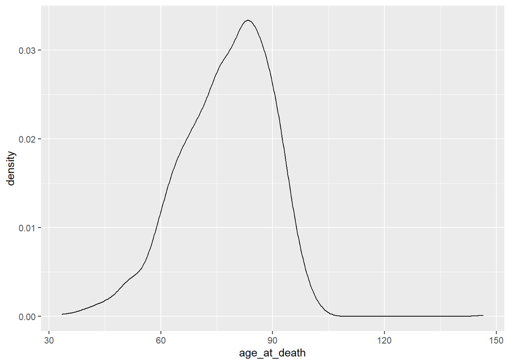

```r
# YOUR CODE HERE

fra_core %>%
  dplyr :: mutate(birth = as.Date(ymd(birth))) %>%
  dplyr :: mutate(death = as.Date(ymd(death))) %>%
  dplyr :: mutate(age_at_death = (death - birth)/365.25) %>%
  ggplot2 :: ggplot(aes(age_at_death)) + geom_density()
```

4. Provide one single table that provides the 5 legislators with the highest and lowest age at death, ignoring ties. [2 points]

```r
# YOUR CODE HERE

fra_core <- fra_core %>%
  dplyr :: mutate(birth = as.Date(ymd(birth))) %>%
  dplyr :: mutate(death = as.Date(ymd(death))) %>%
  dplyr :: mutate(age_at_death = (death - birth)/365.25)

top5 <- fra_core %>%
  arrange(desc(age_at_death)) %>%
  top_n(5)

bottom5 <- fra_core %>%
  arrange(desc(age_at_death)) %>%
  top_n(5)

table <- rbind(top5, bottom5)
table
```

```
   country  pageid wikidataid      wikititle           name  sex ethnicity
1      FRA 6102212   Q3270685   Léon_Arnould   Léon Arnould male      <NA>
2      FRA   65192    Q356724  Antoine_Pinay  Antoine Pinay male     white
3      FRA 8616707  Q18744791 Raymond_Julien Raymond Julien male      <NA>
4      FRA 8759026  Q19630026   Albert_Fouet   Albert Fouet male      <NA>
5      FRA 8786218  Q19359016 Henri_Robichon Henri Robichon male      <NA>
6      FRA 6102212   Q3270685   Léon_Arnould   Léon Arnould male      <NA>
7      FRA   65192    Q356724  Antoine_Pinay  Antoine Pinay male     white
8      FRA 8616707  Q18744791 Raymond_Julien Raymond Julien male      <NA>
9      FRA 8759026  Q19630026   Albert_Fouet   Albert Fouet male      <NA>
10     FRA 8786218  Q19359016 Henri_Robichon Henri Robichon male      <NA>
   religion      birth      death        birthplace        deathplace
1      <NA> 1853-07-07 2000-01-01  48.96556,5.37778              <NA>
2      <NA> 1891-12-30 1994-12-13  45.63222,4.45722  45.47639,4.51472
3      <NA> 1913-09-12 2016-04-24 47.47278,-0.55556 44.80583,-0.63222
```

[output cut: 18 more lines]

5. Find out who has got the longest name and who the shortest (both in terms of number of characters, ignoring whitespace)! [2 points]

```r
# YOUR CODE HERE

table2 <- fra_core %>%
  dplyr :: mutate(name_withoutspace = str_replace_all(name, fixed(" "), "")) %>%
  dplyr :: mutate(name_charactercount = str_length(name_withoutspace)) %>%
  dplyr :: arrange(desc(name_charactercount)) %>%
  dplyr :: slice(c(1, n())) %>%
  dplyr :: select(name, name_charactercount)

table2
```

```
                                     name name_charactercount
1 Marie-Magdeleine Aymé de La Chevrelière                  35
2                                 Éva Sas                   6
```

### Task 2 - Exploring trends in the data [8 points in total]

1. Using data from all sessions, provide a plot that shows the share of female legislators by session! [3 points]

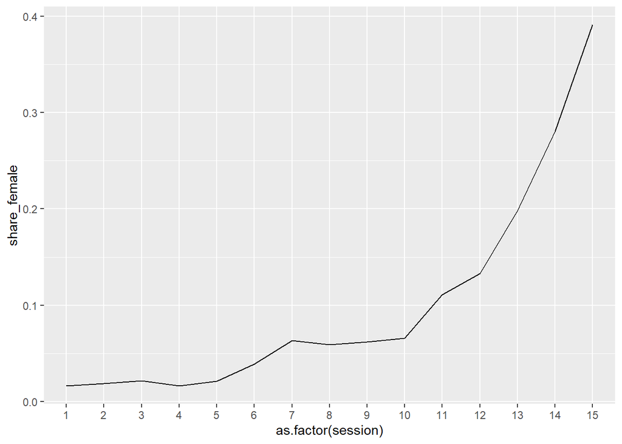

```r
# YOUR CODE HERE

fra_political <- get_political(legislature = "fra")

fra_merge <- left_join(fra_core, fra_political)

fra_merge %>%
  dplyr :: group_by(session, sex) %>%
  dplyr:: summarize(n = n()) %>%
  dplyr:: mutate(share_female = n/sum(n)) %>%
  dplyr :: filter(sex == "female") %>%
  ggplot2 :: ggplot(aes(x = as.factor(session), y = share_female)) + geom_line(group = 1)
```

2. Explore another relation of variables in the dataset. Your analysis should (i) use data from both the `core` and the `political` table and (ii) feature data from several sessions. Also, offer a brief description and interpretation of your findings! [5 points]

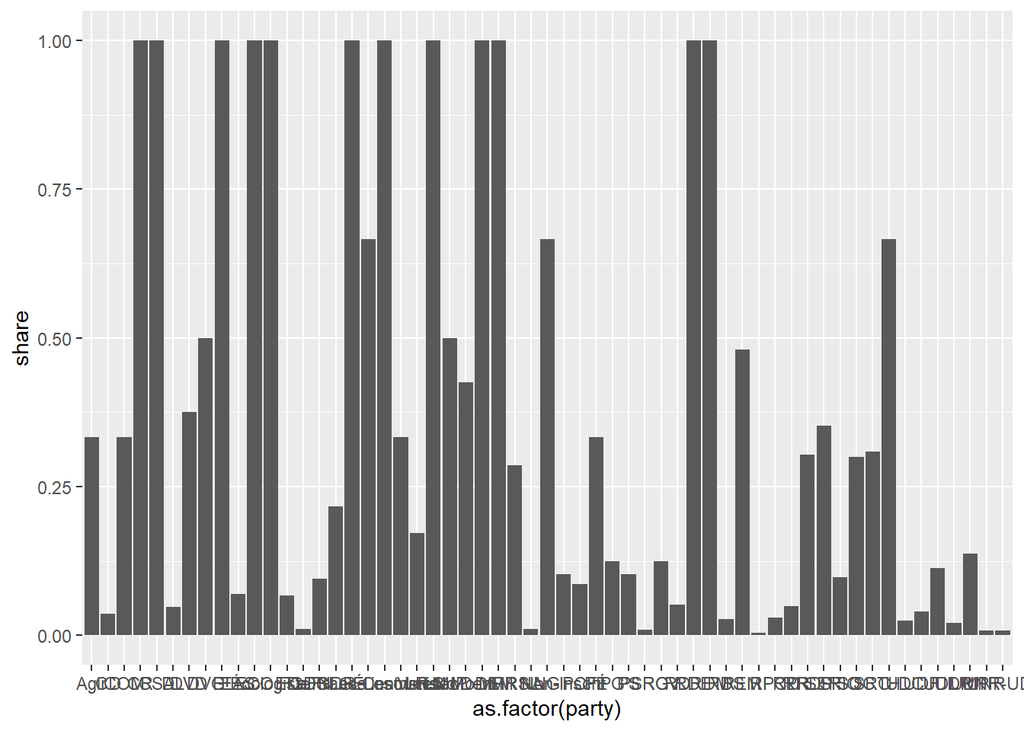

```r
# YOUR CODE HERE

fra_merge %>%
  dplyr :: group_by(party, sex) %>%
  dplyr :: summarize(n = n()) %>%
  dplyr :: mutate(share = n/sum(n)) %>%
  dplyr :: filter(sex == "female") %>%
  ggplot2 :: ggplot(aes(x = as.factor(party), y = share)) + geom_col()
```

```r
# YOUR CODE HERE

 fra_merge %>%
  dplyr :: group_by(sex) %>%
  dplyr :: summarize(n = n()) %>%
  dplyr :: mutate(share = n/sum(n))
```

```
# A tibble: 3 x 3
  sex        n    share
  <chr>  <int>    <dbl>
1 female   930 0.104
2 male    8033 0.896
3 <NA>       7 0.000780
```

The graph above indicates the share of female legislators per party varies greatly. Although there is a considerable number of parties in which women represent 50% or higher, total female share is only 10.4%, as shown in the table above. Therefore, there is still a long way forward to achieve gender equality in the French Assemblée.

### Task 3 - Fun with functions [3 points in total]

1. Program a function `ultimate_answer()` that always returns the number 42, and prove that it works! [1 point]

```r
# YOUR CODE HERE

ultimate_answer <- function(input){return(42)}

ultimate_answer(21)
```

```
[1] 42
```

2. Program a robust function `normalize()` that normalizes a numeric vector x to mean(x) = 0 and sd(x) = 1! Then, apply it to all numeric variables in the mtcars dataset! [2 points]

```r
# YOUR CODE HERE

normalize <- function(input) {
                            normal <- (input - mean(input, na.rm = TRUE))/sd(input, na.rm =  TRUE)
                            return(normal)}

lapply(mtcars, normalize)
```

```
$mpg
 [1]  0.15088482  0.15088482  0.44954345  0.21725341 -0.23073453 -0.33028740
 [7] -0.96078893  0.71501778  0.44954345 -0.14777380 -0.38006384 -0.61235388
[13] -0.46302456 -0.81145962 -1.60788262 -1.60788262 -0.89442035  2.04238943
[19]  1.71054652  2.29127162  0.23384555 -0.76168319 -0.81145962 -1.12671039
[25] -0.14777380  1.19619000  0.98049211  1.71054652 -0.71190675 -0.06481307
[31] -0.84464392  0.21725341

$cyl
 [1] -0.1049878 -0.1049878 -1.2248578 -0.1049878  1.0148821 -0.1049878
 [7]  1.0148821 -1.2248578 -1.2248578 -0.1049878 -0.1049878  1.0148821
[13]  1.0148821  1.0148821  1.0148821  1.0148821  1.0148821 -1.2248578
[19] -1.2248578 -1.2248578 -1.2248578  1.0148821  1.0148821  1.0148821
[25]  1.0148821 -1.2248578 -1.2248578 -1.2248578  1.0148821 -0.1049878
[31]  1.0148821 -1.2248578
```

[output cut: 73 more lines]